[figure not shown]

## # Looping through conditions

Now that we have our movie structure:

[figure not shown]

We can add the movie’s scene components.

We can test to see if this works by running the movie. Click the Run icon on the top right of the *Psychopy* window. Enter ‘001’ as the participant number.

In your *Psychopy* directory, you will now see a *‘data’* subdirectory with the data saved in the form of 001_filename_date.csv. We will discuss the contents of the .csv later.

The movie works, but usually there are many scenes in a movie, and in psychological experiments the scene is often repeated.

In the **Flow**, click the *Insert Loop* button. Click the first dot immediately following *Stimulus* and the second dot immediately before it. A dialog box apears with several options. Name it ‘trials’, the stimulus will loop 5 times by default.  
Run the experiment again.

You will have noticed that there was only one presentation of the kitten scene, any idea why? The kitten scene was actually presented for 1 second, 5 times, but there was no gap between the scenes.

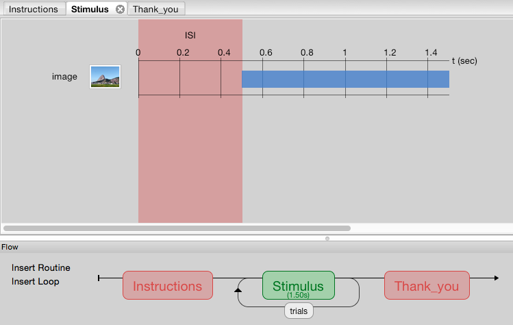

Run the movie again.

So we have 5 scene presentations, but what about recording a response? Let’s add a button press for reaction time and accuracy.  
Click on the in the **Components** panel. There are several options again, type ‘space’ into the *Allowed keys* box to indicate a response by spacebar press. Click OK and the key response appears in the workspace.

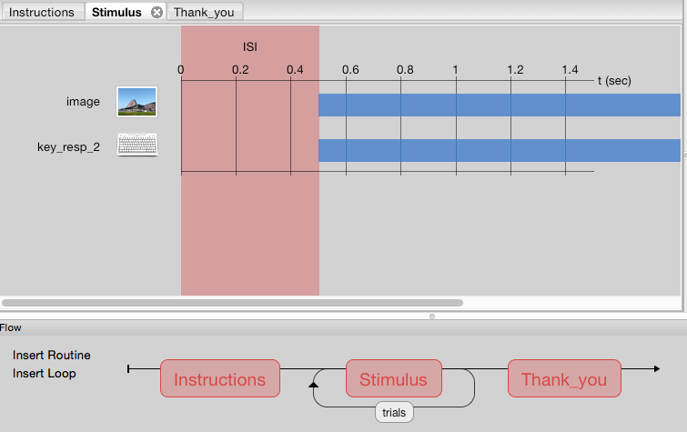

This is good, but we can also loop through different scenes.

Let’s use a new example. Imagine that *Psychopy* is in the pizza delivery business.  
*Psychopy* needs to collect the pizza order and deliver it to the customer, then receive the money. *Psychopy* looks at the list of pizzas to be delivered, and delivers each in turn until there are no more. Similarly, *Psychopy* can collect an image from a list, deliver it to the participant, and then receives a response, continuing until the list is done.

This list can be saved to an excel spreadsheet. In your *images* subdirectory, there is a file called datafile.xlsx. This contains a ready-made list.

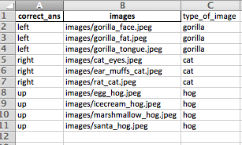

Like the path we entered to the kitten image earlier, the column *images* has a list of paths to images.  
There are additional columns in the spreadsheet, in the pizza example, these can be thought of as the drink and a dessert that accompany the pizza. The drink and dessert in each row are specific to the pizza in that row.

Lets set it up. In this example we will use images of gorillas, kittens and hedgehogs. The instructions are:

*You will see pictures*

*Press left for gorillas*  
*Press right for kittens*  
*Press up for hedgehogs*

*Press spacebar to continue*

Click on *Instructions* in the **Flow**, and select . Type the above into the *Text* box.

To tell *Psychopy* where to look for the datafile, click on *trials* in the **Flow** and select *Browse…*. Select the datafile.xlsx and hit OK. The path to the file is now in the dialog box, and below there will be a summary of what is included. In this spreadsheet there are 10 rows (conditions) with 3 columns (parameters) as shown below.

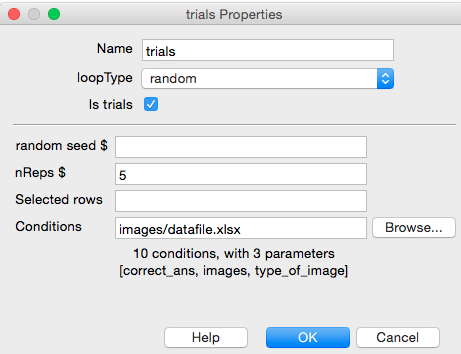

Now, to tell *Psychopy* to deliver the images from this list, click on *Stimulus* in the **Flow**, and the . In the *Image* box, type ‘$images’. The $ tells *Psychopy* to look for the column called *images* in the excel spreadsheet. Change the associated dropdown box to *set every repeat*. The image Properties should look like this:

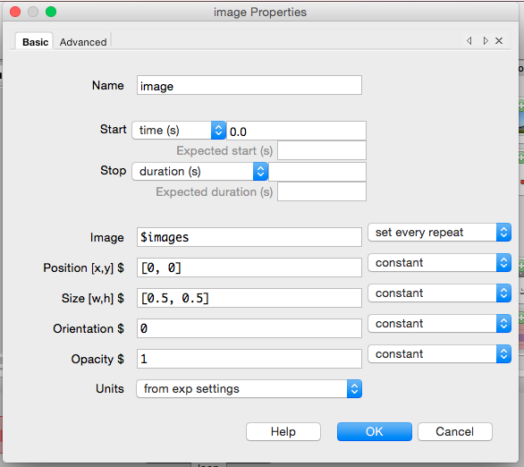

Click OK.

We now need to record the amount of money received following pizza delivery, or the button press recieved following the image delivery. Click the and type ‘’left’, ‘right’, ‘up’ ‘into *Allowed keys*. In the *Store* dropdown, select *first key*. Finally, click the box to *Store correct* and enter’$correct_ ans’ in the *Correct answer* box. As with the image properties, this tells *PsychoPy* to look in the correct_ans column in the excel spreadsheet. Your Properties should resemble the image below.

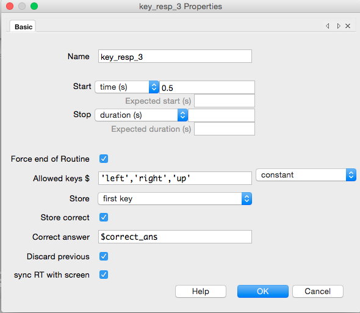

Your scene should now look like this:

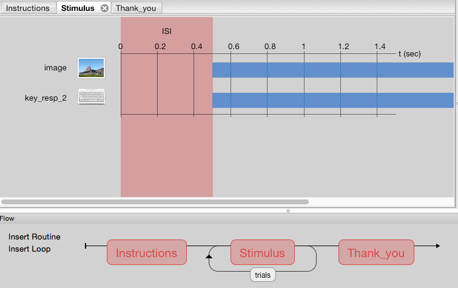